# Taller de Visualizacion en R

Mendez Romina

2019-04-06

tags: { `rladies`, `r`,`ggplot2`,`plotly`,`emoji` }

## Paquetes

Los siguientes son los paquetes que vamos a utilizar durante este taller:`ggplot2`, `reshape2`,`emojifont`y `plotly`. Para instalar un paquete recuerda que debes utilizar la sintaxis:`install.packages('nombrePaquete')`

- ggplot2: Es el paquete para generar graficas.
- reshape2: Es el paquete para obtener el dataset denominado tips, el mismo contiene la información sobre cada propina que recibió un camarero durante unos meses trabajando en un restaurante.
- emojifont: Este paquete nos permite obtener los valores unicode de los emojis.
- plotly: Este paquete permite generar graficas interactivas.

## Gglot2: Grafica en capas

Vamos a realizar el primer scatter plot, para lo cual creamos el dataset tips y posteriormente utlizamos la funcion ggplot para realizar el grafico.

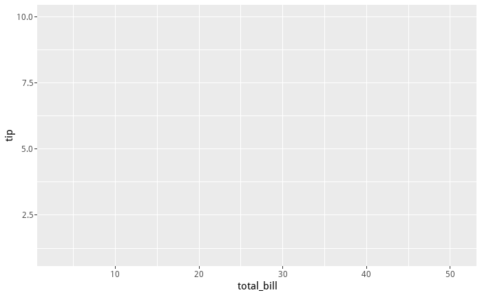

```r
df.tips=tips
ggplot(      df.tips  ,       aes(x=total_bill  ,  y=tip)    )
```

En el grafico anterior, solo vemos los ejes pero necesitamos agregar una geometria para realizar nuestra grafica de scatter plot. Recuerda que para agregar capas debes colocar el signo “+” al finalizar una capa.

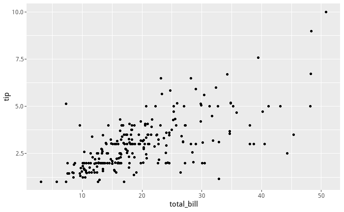

```r
ggplot(      df.tips  ,       aes(x=total_bill  ,  y=tip)    ) +
  geom_point()
```

Vamos agregar las leyendas para que nuestro grafico se vea mas completo!

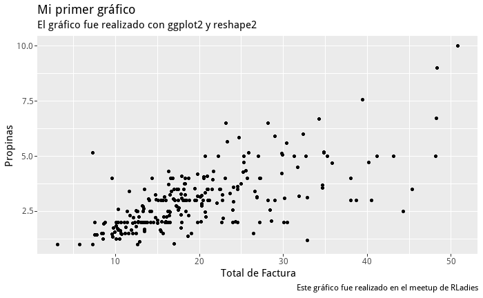

```r
ggplot(      df.tips  ,       aes(x=total_bill  ,  y=tip)    ) +
  geom_point() +
  labs (
        title='Mi primer gráfico',
       subtitle='El gráfico fue realizado con ggplot2 y reshape2',
       x='Total de Factura',
       y='Propinas',
       caption='Este gráfico fue realizado en el meetup de RLadies')
```

Cambiemos un poco mas nuestro grafico, para lo cual agregamos una variables mas para distinguir nuestros puntos en base a si son hombres o mujeres. La variable que nos muestra esto en nuestro grafico es “sex”. Adicionalmente aumentemos el tamaño de nuestros puntos.

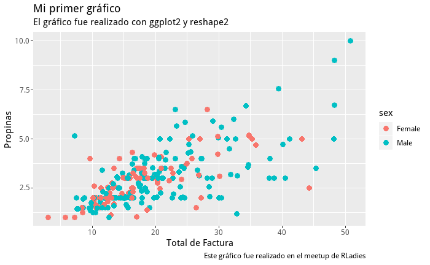

```r
ggplot( df.tips  , aes(x=total_bill , y=tip, color=sex ) ) +
  geom_point( size=3 ) +
  labs (
         title='Mi primer gráfico',
         subtitle='El gráfico fue realizado con ggplot2 y reshape2',
         x='Total de Factura',
         y='Propinas',
         caption='Este gráfico fue realizado en el meetup de RLadies')
```

Podemos agregar otra capa de geometria para cambiar nuestro grafico, en este caso utilizaremos geom_line, y le daremos un color a la linea.

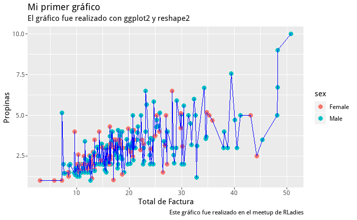

```r
ggplot(tips,aes(x=total_bill,y=tip, color=sex) ) +
  geom_point ( size=3 ) +
  geom_line ( color='blue' ) +
  labs(title='Mi primer gráfico',
       subtitle='El gráfico fue realizado con ggplot2 y reshape2',
       x='Total de Factura',
       y='Propinas',
       caption='Este gráfico fue realizado en el meetup de RLadies')
```

Cambiemos el tema de nuestro grafico, puedes ver que hay una amplia variedad todos ellos comienzacon con theme_(), en este ejemplo utilizaremos theme_minimal()

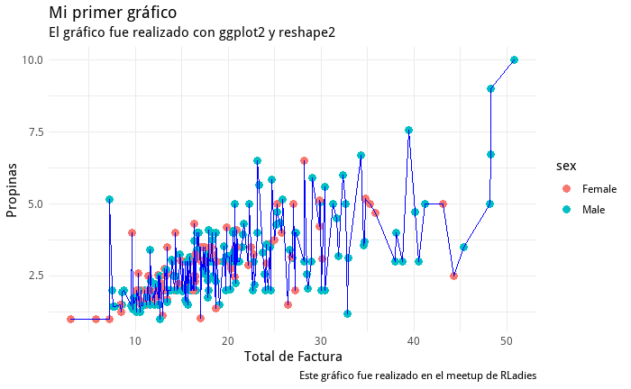

```r
ggplot(tips,aes(x=total_bill,y=tip, color=sex) ) +
  geom_point ( size=3 ) +  geom_line ( color='blue') +
  labs(title='Mi primer gráfico',
       subtitle='El gráfico fue realizado con ggplot2 y reshape2',
       x='Total de Factura',
       y='Propinas',
 caption='Este gráfico fue realizado en el meetup de RLadies') +
theme_minimal()
```

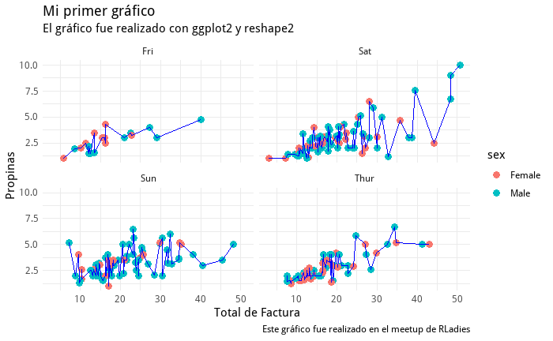

```r
ggplot(tips,aes(x=total_bill,y=tip, color=sex) ) +
  geom_point ( size=3 ) +  geom_line ( color='blue') +
  labs(title='Mi primer gráfico',
       subtitle='El gráfico fue realizado con ggplot2 y reshape2',
       x='Total de Factura',
       y='Propinas',
 caption='Este gráfico fue realizado en el meetup de RLadies') +
theme_minimal ()  +
facet_wrap (.~day)
```

## EMOJIFONT: Grafica con emoticones

Emoji proviene del japones y “e” significa dibujo mientras “moji” significa caracter. Los emoji para utilizarlos se incorporaron al standar Unicode. Unicode es el estándar de codificación de caracteres universal utilizado para la representación de texto para procesamiento del equipo. Unicode proporciona una manera consistente de codificación de texto multilingüe y facilita el intercambio de archivos de texto internacionales.

Si quieres mas informacion sobre [EMOJIFONT](https://cran.r-project.org/web/packages/emojifont/vignettes/emojifont.html) puedes consultar la documentacion. En nuestro caso vamos a buscar emoji que queremos utilizar, para lo cual exise la funcion search_emoji, esta retorna todos los nombre de los emoji en base a un string de busqueda. Veamos un ejemplo:

```r
search_emoji('smile')
```

```
[1] "smiley"      "smile"       "sweat_smile" "smiley_cat"  "smile_cat"
```

Para ver el emoji que cada uno de estos string retorna, podemos ir a la  
[Emoji scheat sheet](https://www.webfx.com/tools/emoji-cheat-sheet/). Ahora selecionamos un alias y utilizamos la funcion emoji para convertirlo en unicode.

```r
emoji('smile')
```

```
[1] "\U0001f604"
```

Ahora vamos a crear una columna nueva del dataset df.tips, con el valor unicode de un emoji. En mi caso yo seleccione corazones (“heart”)!

```r
  df.tips=tips
  df.tips$emoji=emoji("heart")
```

Una vez generada la columna vamos a realizar un grafico, y de esta manera nuestro scatterplot realizara la grafica de corazones

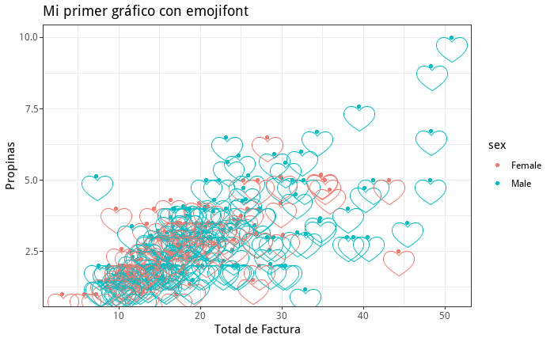

```r
  ggplot(tips,aes(x=total_bill,y=tip,color=sex,label=emoji))+
    geom_point()+
    geom_text(family="EmojiOne", size=12,show.legend = F)+
    labs(title='Mi primer gráfico con emojifont',
         x='Total de Factura',
         y='Propinas') +
    theme_bw()
```

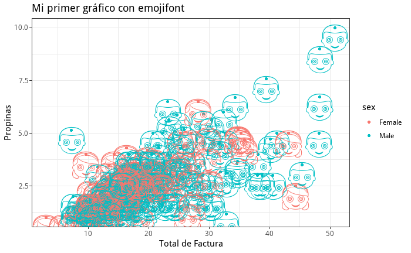

```r
  df.tips=tips
  df.tips$emoji=ifelse(df.tips$sex=='Female', emoji('girl'),emoji('boy') )
  ggplot(df.tips,aes(x=total_bill,y=tip,color=sex,label=emoji))+
    geom_point()+
    geom_text(family="EmojiOne", size=14,show.legend = F)+
    labs(title='Mi primer gráfico con emojifont',
         x='Total de Factura',
         y='Propinas') +
    theme_bw()
```